# Summary Report

This report summarizes the coefficient of variation (CV) and visualizes ridge density distributions across different transformation methods. Additionally, it includes a heatmap illustrating the recall rates based on cancer-type-specific gold-standard proteins, and the expression of the top five proteins identified by the min-score method. The aim is to evaluate the suitability of various mass spectrometry (MS) proteomics quantification formats for deconvolution in identifying cell-type-specific protein expression.

## CV Summary Table

This table presents a statistical summary of the coefficient of variation (CV) across various transformation methods. It includes the mean, median, range of CV values, and the proportion of CVs greater than 0.25 for each method, enabling a comparative assessment of variability and stability introduced by each method.

| Method | Group | Mean | Median | Min | Max | Q1 | Q3 | Prop_GT_0.25 |
| --- | --- | --- | --- | --- | --- | --- | --- | --- |
| Min_score | intensity | 0.452 | 0.445 | 0.204 | 0.807 | 0.373 | 0.514 | 0.990 |
| Min_max | intensity | 0.285 | 0.125 | 0.042 | 3.317 | 0.092 | 0.271 | 0.286 |
| Logistic_like | intensity | 0.011 | 0.009 | 0.003 | 0.045 | 0.007 | 0.016 | 0.000 |
| Quantile | intensity | 0.020 | 0.018 | 0.000 | 0.052 | 0.012 | 0.027 | 0.000 |
| Inverse | intensity | 0.333 | 0.264 | 0.088 | 1.075 | 0.190 | 0.446 | 0.530 |
| Original | intensity | 0.019 | 0.016 | 0.005 | 0.074 | 0.011 | 0.026 | 0.000 |

## CV Ridge Plot

This figure shows the density ridge plot of the CV for each transformation method, allowing for a visual comparison of CV distributions across methods.

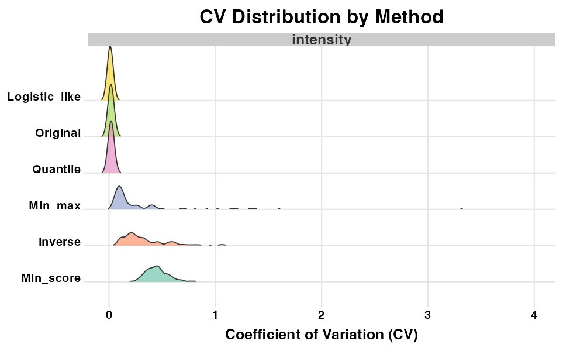

## Recall Heatmap

This plot presents the recall rates of gold-standard proteins of each cell type.

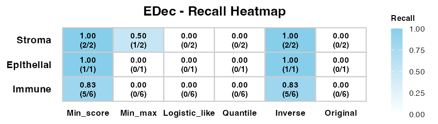

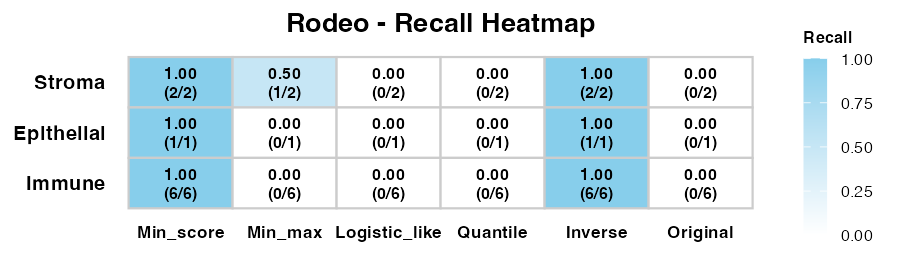

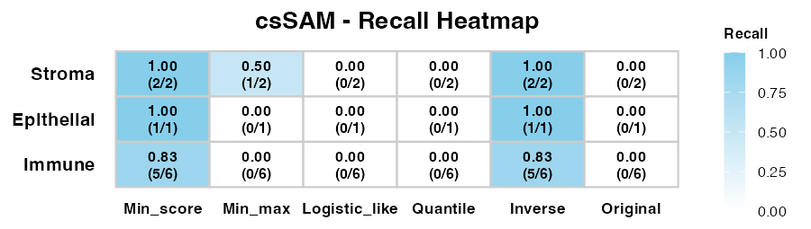

## Marker Barplot (Min_score Method)

This plot shows the specificity of the top five proteins in each cell type, identified by the Min_score.

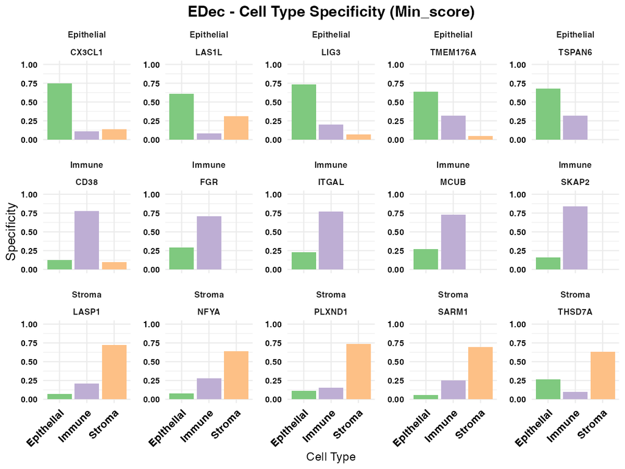

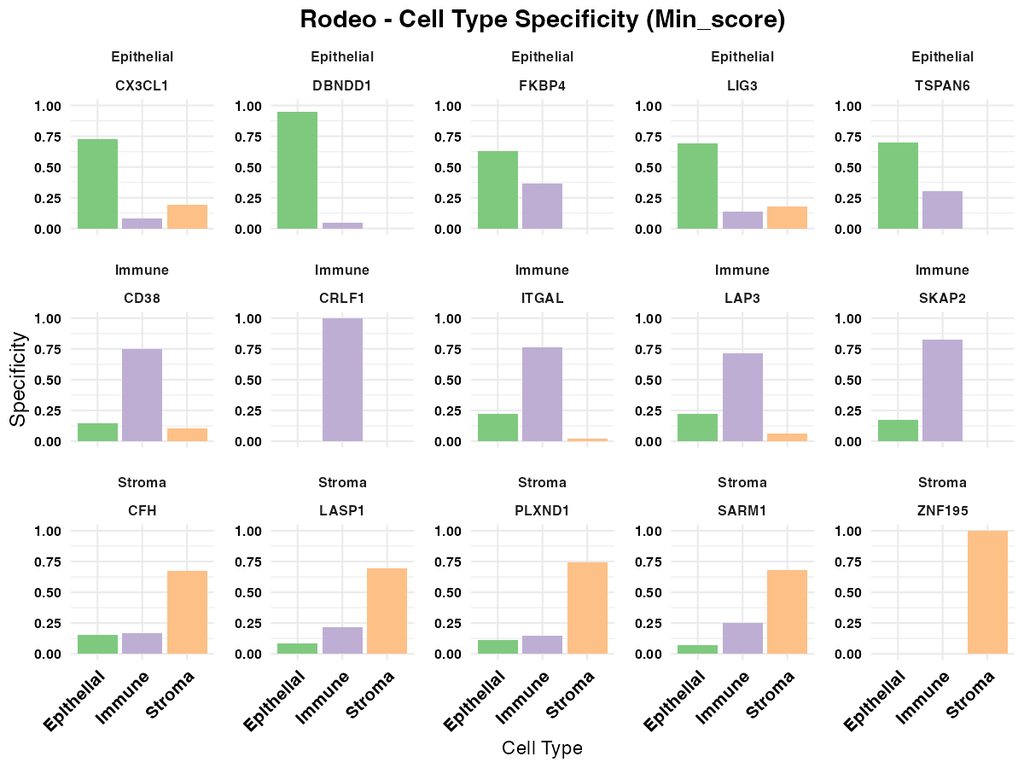

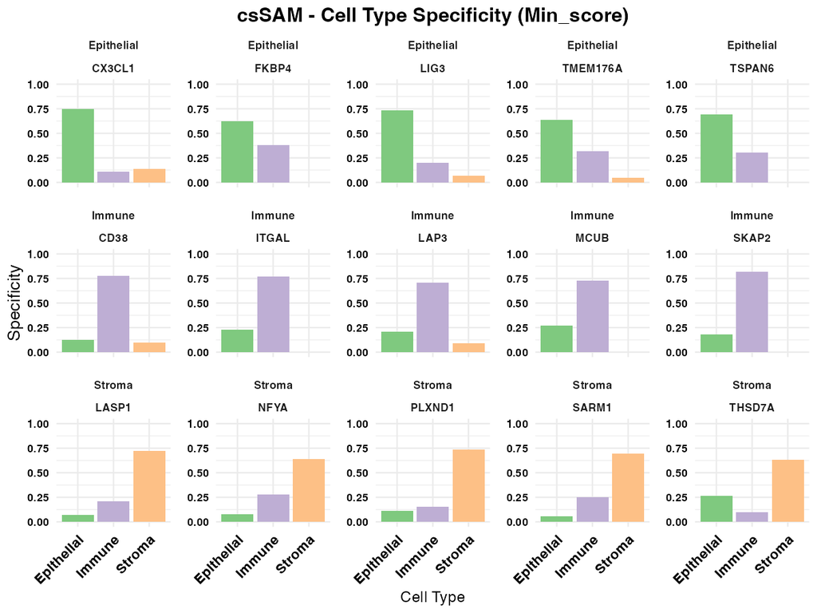